# Final Project: Predicting Article Popularity in Online News Media Using Machine Learning

Xiangyu Xiao and Binyu Yang

2024-04-11

# 1. Data Preparation

```r
# Load the dataset
data <- read.csv("D:/MBAN/Machine Learning and AI/FInal/online+news+popularity/OnlineNewsPopularity/OnlineNewsPopularity.csv")
```

```r
# Check for missing values
sum(is.na(data))
```

```
## [1] 0
```

```r
# There are no missing values in the dataset
```

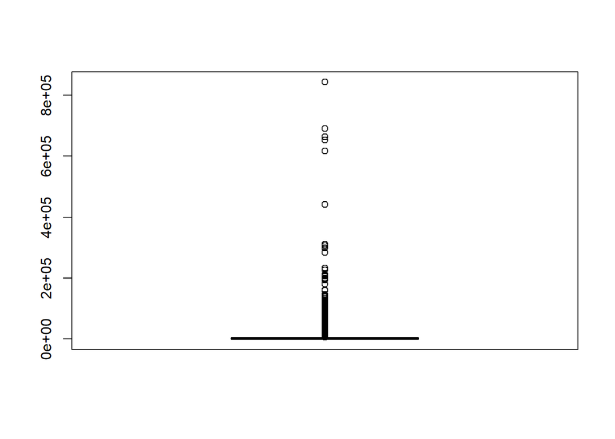

```r
# Check for outliers of the target variable
boxplot(data$shares)
```

```r
# As we see many outliers here, we need to remove those outliers. We use the IQR method to remove the outliers.
```

```r
# Remove outliers
library(dplyr)
# Calculate the quartiles and IQR for the variable
Q1 <- quantile(data$shares, 0.25)
Q3 <- quantile(data$shares, 0.75)
IQR <- Q3 - Q1

# Define the bounds for what is considered an outlier
lower_bound <- Q1 - 1.5 * IQR
upper_bound <- Q3 + 1.5 * IQR

# Filter out the rows where the variable is an outlier
data_no_outliers <- data %>%
  filter(data$shares >= lower_bound & data$shares <= upper_bound)
```

# 2. EDA

```r
# Correlation between the variables
# Select only numeric columns
numeric_data <- select_if(data_no_outliers, is.numeric)

# Now you can compute the correlation matrix
correlation_matrix <- cor(numeric_data)

# View the correlation matrix
print(correlation_matrix)
```

[output not shown]

[output cut: 1653 more lines]

```
## global_rate_positive_words                    0.1069234459  0.063263287
## global_rate_negative_words                    0.0568251329 -0.025460710
## rate_positive_words                          -0.0008198548  0.044742348
## rate_negative_words                          -0.0268572025 -0.067573229
## avg_positive_polarity                         0.0957580667  0.019006505
## min_positive_polarity                         0.0081614742 -0.032038128
## max_positive_polarity                         0.0810995678  0.033220447
## avg_negative_polarity                        -0.0750291863 -0.003511512
## min_negative_polarity                        -0.0583644605 -0.004899245
## max_negative_polarity                        -0.0174455186  0.003100281
## title_subjectivity                            0.7162359621  0.025858813
## title_sentiment_polarity                      0.4021626338  0.045289204
## abs_title_subjectivity                       -0.4126119670  0.004831034
## abs_title_sentiment_polarity                  1.0000000000  0.029515150
## shares                                        0.0295151503  1.000000000
```

```r
# Showing descriptives
summary(data_no_outliers)
```

```
##      url              timedelta     n_tokens_title n_tokens_content
##  Length:35103       Min.   :  8.0   Min.   : 2.0   Min.   :   0.0
##  Class :character   1st Qu.:162.0   1st Qu.: 9.0   1st Qu.: 250.0
##  Mode  :character   Median :337.0   Median :10.0   Median : 414.0
##                     Mean   :353.7   Mean   :10.4   Mean   : 546.8
##                     3rd Qu.:545.0   3rd Qu.:12.0   3rd Qu.: 715.0
##                     Max.   :731.0   Max.   :20.0   Max.   :7764.0
##  n_unique_tokens  n_non_stop_words n_non_stop_unique_tokens   num_hrefs
##  Min.   :0.0000   Min.   :0.0000   Min.   :0.0000           Min.   :  0.00
##  1st Qu.:0.4718   1st Qu.:1.0000   1st Qu.:0.6276           1st Qu.:  4.00
##  Median :0.5387   Median :1.0000   Median :0.6912           Median :  7.00
##  Mean   :0.5313   Mean   :0.9724   Mean   :0.6748           Mean   : 10.58
##  3rd Qu.:0.6070   3rd Qu.:1.0000   3rd Qu.:0.7545           3rd Qu.: 13.00
##  Max.   :1.0000   Max.   :1.0000   Max.   :1.0000           Max.   :187.00
##  num_self_hrefs       num_imgs         num_videos     average_token_length
##  Min.   :  0.000   Min.   :  0.000   Min.   : 0.000   Min.   :0.000
##  1st Qu.:  1.000   1st Qu.:  1.000   1st Qu.: 0.000   1st Qu.:4.482
##  Median :  3.000   Median :  1.000   Median : 0.000   Median :4.668
##  Mean   :  3.297   Mean   :  4.336   Mean   : 1.188   Mean   :4.560
##  3rd Qu.:  4.000   3rd Qu.:  3.000   3rd Qu.: 1.000   3rd Qu.:4.859
##  Max.   :116.000   Max.   :128.000   Max.   :75.000   Max.   :8.042
##   num_keywords    data_channel_is_lifestyle data_channel_is_entertainment
##  Min.   : 1.000   Min.   :0.00000           Min.   :0.0000
##  1st Qu.: 6.000   1st Qu.:0.00000           1st Qu.:0.0000
##  Median : 7.000   Median :0.00000           Median :0.0000
##  Mean   : 7.199   Mean   :0.05122           Mean   :0.1808
##  3rd Qu.: 9.000   3rd Qu.:0.00000           3rd Qu.:0.0000
##  Max.   :10.000   Max.   :1.00000           Max.   :1.0000
##  data_channel_is_bus data_channel_is_socmed data_channel_is_tech
##  Min.   :0.0000      Min.   :0.00000        Min.   :0.0000
##  1st Qu.:0.0000      1st Qu.:0.00000        1st Qu.:0.0000
##  Median :0.0000      Median :0.00000        Median :0.0000
##  Mean   :0.1638      Mean   :0.05666        Mean   :0.1866
##  3rd Qu.:0.0000      3rd Qu.:0.00000        3rd Qu.:0.0000
##  Max.   :1.0000      Max.   :1.00000        Max.   :1.0000
##  data_channel_is_world   kw_min_min       kw_max_min       kw_avg_min
##  Min.   :0.0000        Min.   : -1.00   Min.   :     0   Min.   :   -1.0
##  1st Qu.:0.0000        1st Qu.: -1.00   1st Qu.:   444   1st Qu.:  140.7
##  Median :0.0000        Median : -1.00   Median :   654   Median :  234.3
##  Mean   :0.2244        Mean   : 26.23   Mean   :  1122   Mean   :  306.7
```

[output cut: 71 more lines]

```
##  Max.   : 0.0000       Max.   : 0.0000       Max.   : 0.0000
##  title_subjectivity title_sentiment_polarity abs_title_subjectivity
##  Min.   :0.0000     Min.   :-1.00000         Min.   :0.0000
##  1st Qu.:0.0000     1st Qu.: 0.00000         1st Qu.:0.1667
##  Median :0.1250     Median : 0.00000         Median :0.5000
##  Mean   :0.2769     Mean   : 0.06861         Mean   :0.3420
##  3rd Qu.:0.5000     3rd Qu.: 0.13636         3rd Qu.:0.5000
##  Max.   :1.0000     Max.   : 1.00000         Max.   :0.5000
##  abs_title_sentiment_polarity     shares
##  Min.   :0.000                Min.   :   1
##  1st Qu.:0.000                1st Qu.: 903
##  Median :0.000                Median :1300
##  Mean   :0.152                Mean   :1672
##  3rd Qu.:0.250                3rd Qu.:2100
##  Max.   :1.000                Max.   :5500
```

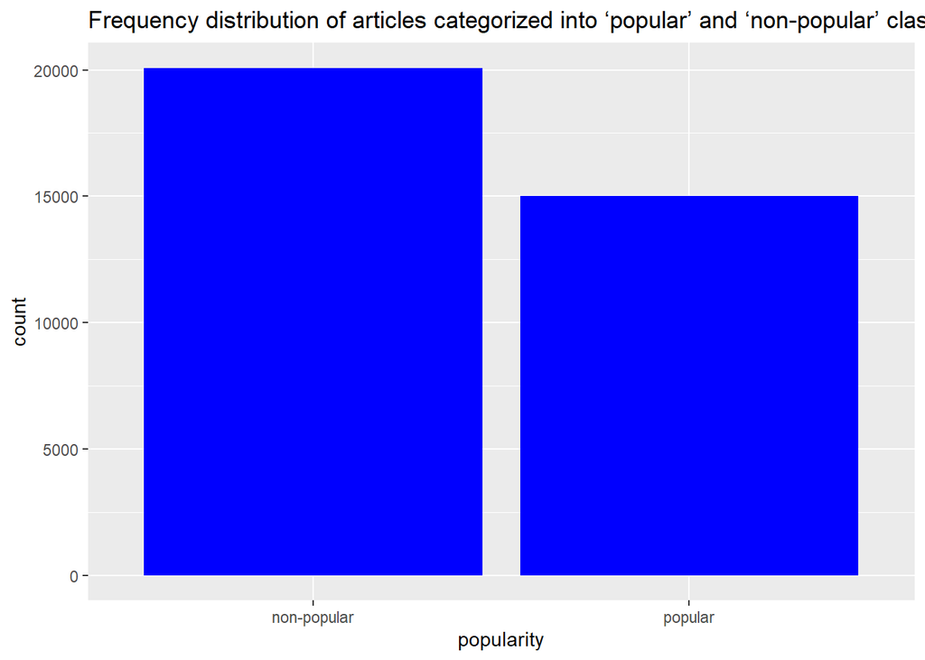

```r
# Displaying the frequency distribution of articles categorized into ‘popular’ and ‘non-popular’ classes
library(ggplot2)
data_no_outliers$popularity <- ifelse(data_no_outliers$shares > 1400, "popular", "non-popular")
ggplot(data_no_outliers, aes(x = popularity)) + geom_bar(fill = "blue") + labs(title = "Frequency distribution of articles categorized into ‘popular’ and ‘non-popular’ classes")
```

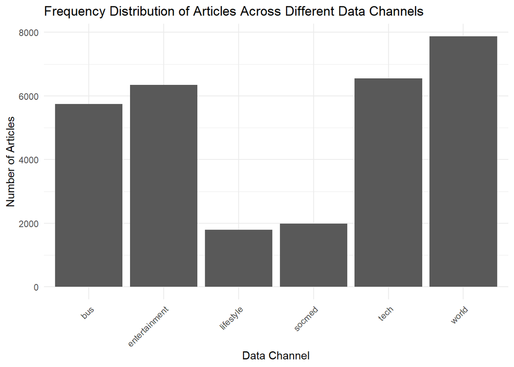

```r
# Frequency distribution of articles across different data channels (Lifestyle, Entertainment, Business, Social Media, Technology, and World), distribute in onr graph
library(dplyr)
library(ggplot2)
library(tidyr)

# Gather the data channel columns into key-value pairs
data_long <- data_no_outliers %>%
  select(starts_with("data_channel_is_")) %>%
  pivot_longer(cols = everything(), names_to = "Channel", values_to = "Frequency") %>%
  group_by(Channel) %>%
  summarise(Frequency = sum(Frequency)) %>%
  mutate(Channel = sub("data_channel_is_", "", Channel)) # Clean up the channel names

# Now, create the bar plot
ggplot(data_long, aes(x = Channel, y = Frequency)) +
  geom_bar(stat = "identity") +
  theme_minimal() +
  xlab("Data Channel") +
  ylab("Number of Articles") +
  ggtitle("Frequency Distribution of Articles Across Different Data Channels") +
  theme(axis.text.x = element_text(angle = 45, hjust = 1)) # Rotate the x labels for better readability
```

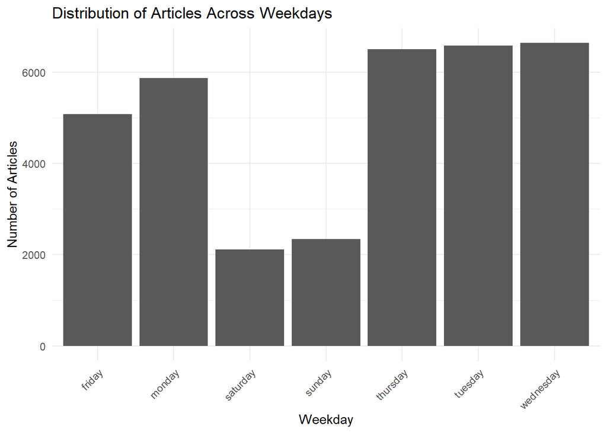

```r
# Frequency distribution of articles published on different weekdays (Monday, Tuesday, Wednesday, Thursday, Friday, Saturday, and Sunday)
# Gather the weekday columns into key-value pairs
weekday_data_long <- data_no_outliers %>%
  select(starts_with("weekday_is_")) %>%
  pivot_longer(cols = everything(), names_to = "Weekday", values_to = "Frequency") %>%
  group_by(Weekday) %>%
  summarise(Frequency = sum(Frequency)) %>%
  mutate(Weekday = sub("weekday_is_", "", Weekday)) # Clean up the Weekday names

# Create the distribution graph for weekdays
ggplot(weekday_data_long, aes(x = Weekday, y = Frequency)) +
  geom_bar(stat = "identity") +
  theme_minimal() +
  xlab("Weekday") +
  ylab("Number of Articles") +
  ggtitle("Distribution of Articles Across Weekdays") +
  theme(axis.text.x = element_text(angle = 45, hjust = 1)) # Rotate the x labels for readability
```

```r
# Cross-tabulation of the number of articles published on different weekdays and channels
# Convert data channels from wide to long format
data_long <- data_no_outliers %>%
  pivot_longer(cols = starts_with("data_channel_is_"), names_to = "DataChannel", values_to = "ChannelValue") %>%
  pivot_longer(cols = starts_with("weekday_is_"), names_to = "Weekday", values_to = "WeekdayValue") %>%
  filter(ChannelValue == 1, WeekdayValue == 1) %>%
  mutate(DataChannel = sub("data_channel_is_", "", DataChannel),
         Weekday = sub("weekday_is_", "", Weekday)) %>%
  select(-ChannelValue, -WeekdayValue)

# Ensure unique rows for the combination of articles, DataChannel, and Weekday
data_long <- distinct(data_long)

# Step 2: Cross-tabulation
cross_tab <- with(data_long, table(DataChannel, Weekday))

# View the cross-tabulation results
print(cross_tab)
```

```
##                Weekday
## DataChannel     friday monday saturday sunday thursday tuesday wednesday
##   bus              773   1049      207    306     1155    1083      1176
##   entertainment    875   1218      334    449     1113    1172      1186
##   lifestyle        267    275      152    173      306     289       336
##   socmed           276    282      162    111      400     398       360
##   tech             901   1107      453    332     1192    1311      1253
##   world           1234   1252      475    521     1467    1448      1481
```

# 3. Regression

First, we use random forest to predict the number of shares an article will get Random Forest is an ensemble learning method that is good for handling non-linear data with interactions between variables. It is robust to overfitting and can handle a large number of features. OOB error, which is an average error of predictions on each training sample xᵢ, using only the trees that did not have xᵢ in their bootstrap sample, can be used for model evaluation.

Advantages:

Good for complex datasets with non-linear relationships.

It has built-in methods for estimating model performance (OOB error).

It can handle missing data to a certain extent and doesn’t require feature scaling.

Disadvantages:

Can be slow to train with very large datasets. Less interpretable than linear models.

```r
# Random Forest Model
library(randomForest)

# Use parallel processing for faster training
library(doParallel)
cl <- makeCluster(detectCores() - 1)  # Use all cores except one
registerDoParallel(cl)

data_no_outliers$url <- NULL  # Remove the 'url' column
data_no_outliers$shares <- as.numeric(data_no_outliers$shares)

# Split the data into training and testing
set.seed(123)  # Setting seed for reproducibility
train_indices <- sample(seq_len(nrow(data_no_outliers)), size = floor(0.8 * nrow(data_no_outliers)))
train_data <- data_no_outliers[train_indices, ]
test_data <- data_no_outliers[-train_indices, ]
train_data$popularity <- NULL
test_data$popularity <- NULL

rf_model <- randomForest(shares ~ ., data = train_data, ntree = 500)
# Print the model
rf_model
```

```
##
## Call:
##  randomForest(formula = shares ~ ., data = train_data, ntree = 500)
##                Type of random forest: regression
##                      Number of trees: 500
## No. of variables tried at each split: 19
##
##           Mean of squared residuals: 1048806
##                     % Var explained: 13.4
```

```r
# Prediction and RMSPE calculation
rf_predictions <- predict(rf_model, newdata = test_data)
rf_rmspe <- sqrt(mean((test_data$shares - rf_predictions)^2)) / mean(test_data$shares)
print(paste("RMSPE for Random Forest:", rf_rmspe))
```

```
## [1] "RMSPE for Random Forest: 0.620274006828296"
```

```r
# OOB
rf_oob <- rf_model$err.rate[nrow(rf_model$err.rate), "OOB"]
rf_oob
```

[output not shown]

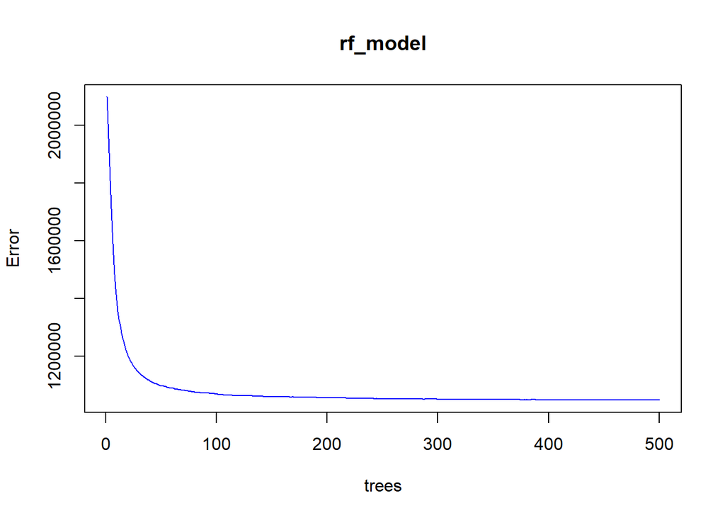

```r
plot(rf_model, col = "blue")
```

# The second model we use is the GBM model.

GBM is a type of ensemble learning technique, where multiple models (typically decision trees) are combined to improve predictive performance. It builds the model in a stage-wise fashion; it constructs new models that predict the residuals or errors of prior models and then combines them into the final prediction.

Advantages:

GBM can deliver highly accurate predictions, often outperforming other machine learning algorithms.

It can be used for both classification and regression tasks.

GBM is capable of handling data with complex and non-linear relationships.

GBM naturally ranks features by their importance, which is useful for feature selection.

Disadvantages:

If not tuned properly, GBM models can easily overfit, especially on small datasets.

Training GBM models can be computationally intensive and time-consuming, especially with large datasets and a high number of trees.

There are several hyperparameters (like number of trees, depth of trees, learning rate) that need careful tuning to avoid overfitting and underfitting.

While individual trees are easy to interpret, a whole ensemble of trees (as used in GBM) can be difficult to interpret compared to simpler models.

```r
# GBM Model
library(gbm)
set.seed(123)  # Setting seed for reproducibility
# Exclude the 'popularity' variable from the training dataset
train_data$popularity <- NULL
# Fit the model - start with default settings and adjust as necessary
gbm_model <- gbm(shares ~ .,
                 data = train_data,
                 distribution = "gaussian", # for regression
                 n.trees = 500,
                 interaction.depth = 3,
                 shrinkage = 0.01,
                 cv.folds = 5, # for cross-validation
                 n.minobsinnode = 10,
                 verbose = FALSE)
best_trees <- gbm.perf(gbm_model, method = "cv")
```

[figure not shown]

```r
# Predict on the test set
test_pred <- predict(gbm_model, newdata = test_data, n.trees = best_trees)
```

```r
# OOB
gbm_oob <- gbm_model$train.error[best_trees]
gbm_oob
```

```
## [1] 1049020
```

```r
# Calculate the RMSPE
gbm_rmspe <- sqrt(mean((test_data$shares - test_pred)^2)) / mean(test_data$shares)
print(paste("RMSPE for GBM:", gbm_rmspe))
```

```
## [1] "RMSPE for GBM: 0.625605120205234"
```

We use LPM as the benchmark model

```r
# Linear Regression Model
lm_model <- lm(shares ~ ., data = train_data)
lm_predictions <- predict(lm_model, newdata = test_data)
lm_rmspe <- sqrt(mean((test_data$shares - lm_predictions)^2)) / mean(test_data$shares)

lm_rmspe
```

```
## [1] 0.6317187
```

Compare those models, we can see that The Random Forest model has the lowest RMSPE of approximately 62.02%, making it the best performer among the three in terms of prediction accuracy relative to the actual values.

```r
# Improvements in predictive accuracy compared to the benchmark model
print(paste("Improvement in RMSPE over the benchmark model (Linear Regression):", rf_rmspe - lm_rmspe))
```

```
## [1] "Improvement in RMSPE over the benchmark model (Linear Regression): -0.0114446739684028"
```

```r
#Random Forest Feature Importance
# Extract feature importance
rf_importance <- importance(rf_model)

# Sort the importances in decreasing order, keeping the names attached
rf_sorted <- sort(rf_importance[, 1], decreasing = TRUE)  # Make sure to select the correct importance metric column

# Get the names of the top 10 most important features
top_features <- names(rf_sorted)[1:10]

# Print the names and importance scores of the top 10 features
print("Top 10 most important features in Random Forest:")
```

```
## [1] "Top 10 most important features in Random Forest:"
```

```r
print(top_features)
```

```
##  [1] "kw_avg_avg"                "kw_max_avg"
##  [3] "timedelta"                 "LDA_00"
##  [5] "LDA_04"                    "LDA_02"
##  [7] "LDA_01"                    "kw_avg_max"
##  [9] "self_reference_min_shares" "LDA_03"
```

```r
print(rf_sorted[1:10])
```

```
##                kw_avg_avg                kw_max_avg                 timedelta
##                1536294821                1248049647                1106965489
##                    LDA_00                    LDA_04                    LDA_02
##                1066104080                 983860358                 967967997
##                    LDA_01                kw_avg_max self_reference_min_shares
##                 957251273                 945569798                 924452507
##                    LDA_03
##                 898334227
```

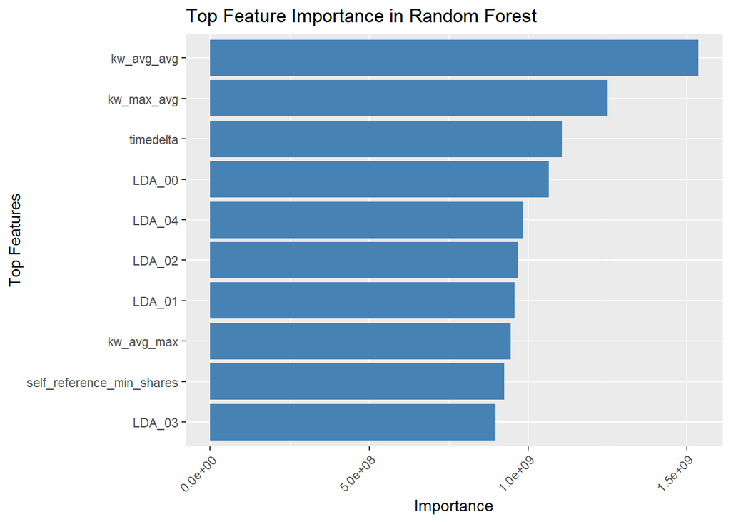

```r
# Base on the feature importance above, we can create a bar plot to visualize the top 10 most important features
# Load the ggplot2 library
library(ggplot2)

# Create a vector of feature names
features <- c("kw_avg_avg", "kw_max_avg", "timedelta", "LDA_02",
              "LDA_00", "LDA_04", "LDA_01", "self_reference_min_shares",
              "kw_avg_max", "LDA_03")

# Create a vector of feature importance scores
importances <- c(1536294821, 1248049647, 1106965489, 967967997,
                 1066104080, 983860358, 957251273, 924452507,
                 945569798, 898334227)

# Combine into a data frame
rf_imp_df <- data.frame(Feature = features, Importance = importances)

# Create a bar plot for the top 10 most important features
ggplot(rf_imp_df, aes(x = reorder(Feature, Importance), y = Importance)) +
  geom_bar(stat = "identity", fill = "steelblue") +
  labs(title = "Top Feature Importance in Random Forest", x = "Top Features", y = "Importance") +
  theme(axis.text.x = element_text(angle = 45, hjust = 1, vjust = 1)) +
  coord_flip()  # Flipping the coordinates for better readability
```

The Random Forest model outperformed the GBM and LPM models in terms of prediction accuracy, with an RMSPE of 62.02%. From this visualization, we can conclude that keyword-related features have a prominent role in the model’s decisions, indicating the relevance of keyword metrics to the outcome variable. Additionally, several LDA (Latent Dirichlet Allocation) features also contribute meaningfully, suggesting that topics generated by LDA are useful for prediction in the given context. The feature timedelta also appears as an important factor, which may indicate that time-related aspects are significant in the model.

# 4. Classification

First, we use logistic regression to predict whether an article will be popular or not based on the number of shares it receives.Logistic regression is a statistical method used for binary classification, which predicts the probability that an observation belongs to one of two categories.

Advantages:

Provides probabilities for outcomes, which are easy to interpret.

It is computationally inexpensive, making it highly efficient to train.

Offers good performance for linearly separable classes.

Gives a more informative result in terms of the likelihood of observations.

Disadvantages:

It assumes a linear relationship between the logit of the outcome and each predictor variables.

It is typically restricted to binary classification problems.

Performance can be negatively impacted by unbalanced data, leading to biased models.

Susceptible to outliers and noisy data, which can distort the model’s performance.

```r
# Logistic Regression Model
# Convert the target variable 'shares' to a binary variable 'popularity'
data_no_outliers$popularity <- ifelse(data_no_outliers$shares > 1400, 1, 0)
data_no_outliers$shares <- NULL  # Remove the 'shares' column

# Split the data into training and testing
set.seed(123)  # Setting seed for reproducibility
train_indices <- sample(seq_len(nrow(data_no_outliers)), size = floor(0.8 * nrow(data_no_outliers)))
train_data <- data_no_outliers[train_indices, ]
test_data <- data_no_outliers[-train_indices, ]

# Fit the logistic regression model
logit_model <- glm(popularity ~ ., data = train_data, family = "binomial")
logit_model
```

```
##
## Call:  glm(formula = popularity ~ ., family = "binomial", data = train_data)
##
## Coefficients:
##                   (Intercept)                      timedelta
##                    -6.109e-01                     -7.321e-05
##                n_tokens_title               n_tokens_content
##                    -4.034e-03                      1.717e-04
##               n_unique_tokens               n_non_stop_words
##                     3.799e-02                     -9.762e+00
##      n_non_stop_unique_tokens                      num_hrefs
##                    -8.553e-01                      5.562e-03
##                num_self_hrefs                       num_imgs
##                    -1.966e-02                     -2.591e-04
##                    num_videos           average_token_length
##                    -1.072e-03                     -7.722e-02
##                  num_keywords      data_channel_is_lifestyle
##                     3.536e-02                     -1.489e-01
## data_channel_is_entertainment            data_channel_is_bus
##                    -2.836e-01                     -2.257e-01
##        data_channel_is_socmed           data_channel_is_tech
##                     8.272e-01                      4.909e-01
##         data_channel_is_world                     kw_min_min
##                    -3.805e-02                      1.627e-03
##                    kw_max_min                     kw_avg_min
##                     4.468e-05                     -2.979e-04
##                    kw_min_max                     kw_max_max
##                    -4.343e-07                     -4.309e-07
##                    kw_avg_max                     kw_min_avg
##                    -5.889e-07                     -5.288e-05
##                    kw_max_avg                     kw_avg_avg
##                    -7.615e-05                      5.870e-04
##     self_reference_min_shares      self_reference_max_shares
##                     2.490e-07                      3.917e-07
##    self_reference_avg_sharess              weekday_is_monday
##                     2.112e-06                     -7.371e-01
##            weekday_is_tuesday           weekday_is_wednesday
##                    -8.221e-01                     -8.451e-01
##           weekday_is_thursday              weekday_is_friday
##                    -7.720e-01                     -5.785e-01
```

[output cut: 13 more lines]

```
##                     1.053e+01                      1.002e+01
##         avg_positive_polarity          min_positive_polarity
##                    -2.338e-01                     -3.932e-01
##         max_positive_polarity          avg_negative_polarity
##                    -2.200e-02                      9.834e-02
##         min_negative_polarity          max_negative_polarity
##                     3.184e-02                      3.475e-02
##            title_subjectivity       title_sentiment_polarity
##                     2.011e-01                      2.332e-01
##        abs_title_subjectivity   abs_title_sentiment_polarity
##                     2.957e-01                     -1.034e-01
##
## Degrees of Freedom: 28081 Total (i.e. Null);  28025 Residual
## Null Deviance:       38340
## Residual Deviance: 35070     AIC: 35180
```

```r
# Predictions and Evaluation
# Predict on the test set
logit_predictions <- predict(logit_model, newdata = test_data, type = "response")
logit_predictions <- ifelse(logit_predictions > 0.5, 1, 0)

# Confusion matrix
conf_matrix <- table(test_data$popularity, logit_predictions)
print(conf_matrix)
```

```
##    logit_predictions
##        0    1
##   0 3167  848
##   1 1553 1453
```

```r
# Calculate accuracy
accuracy <- sum(diag(conf_matrix)) / sum(conf_matrix)
print(paste("Accuracy of Logistic Regression:", accuracy))
```

```
## [1] "Accuracy of Logistic Regression: 0.6580259222333"
```

```r
# Calculate precision
precision <- conf_matrix[2, 2] / sum(conf_matrix[, 2])
print(paste("Precision of Logistic Regression:", precision))
```

```
## [1] "Precision of Logistic Regression: 0.631464580617123"
```

```r
# Calculate recall
recall <- conf_matrix[2, 2] / sum(conf_matrix[2, ])
print(paste("Recall of Logistic Regression:", recall))
```

```
## [1] "Recall of Logistic Regression: 0.483366600133067"
```

```r
# Calculate F1 score
f1_score <- 2 * (precision * recall) / (precision + recall)
print(paste("F1 Score of Logistic Regression:", f1_score))
```

```
## [1] "F1 Score of Logistic Regression: 0.547578669681553"
```

```r
# Calculate AUC
library(pROC)
roc_obj <- roc(test_data$popularity, logit_predictions)
auc <- auc(roc_obj)
print(paste("AUC of Logistic Regression:", auc))
```

```
## [1] "AUC of Logistic Regression: 0.636079315010494"
```

Then, we use decision tree model to do the same task.A decision tree consists of nodes that form a root, branches, and leaf nodes at the ends. Each internal node represents a “test” on an attribute, each branch represents the outcome of the test, and each leaf node represents a class label (in classification) or a continuous value (in regression).

Advantages:

Trees can be visualized, making them easy to interpret even without statistical knowledge.

Can manage categorical and numerical data.

Doesn’t assume a linear relationship and doesn’t require much data preparation.

The features used at the top of the tree contribute the most to the decision process, indicating their importance.

Disadvantages:

Decision trees can create overly complex trees that do not generalize well to new data.

This can be mitigated by pruning.

Small changes in the data can result in a completely different tree being generated.

Trees can be biased toward classes that dominate if the class balance isn’t addressed. They are not ideal for tasks where relationships between features are non-linear.

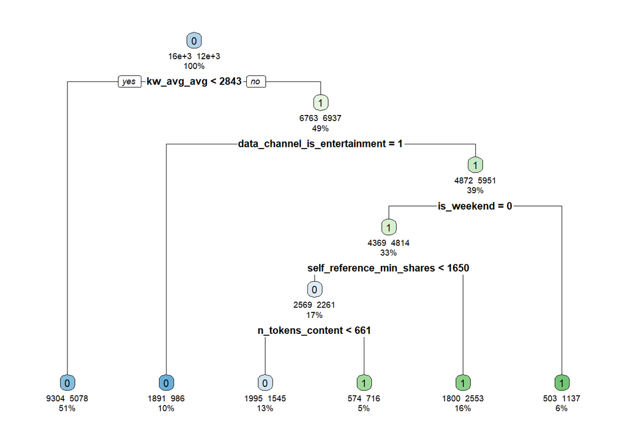

```r
# Decision Tree Model
library(rpart)
library(rpart.plot)

# Fit the decision tree model
dt_model <- rpart(popularity ~ ., data = train_data, method = "class")
# Plot the decision tree
rpart.plot(dt_model, extra = 101, type = 2, fallen.leaves = TRUE, under = TRUE, faclen = 0)
```

```r
# Predictions and Evaluation
# Predict on the test set
dt_predictions <- predict(dt_model, newdata = test_data, type = "class")

# Confusion matrix
conf_matrix_dt <- table(test_data$popularity, dt_predictions)
print(conf_matrix_dt)
```

```
##    dt_predictions
##        0    1
##   0 3312  703
##   1 1929 1077
```

```r
# Calculate accuracy
accuracy_dt <- sum(diag(conf_matrix_dt)) / sum(conf_matrix_dt)
print(paste("Accuracy of Decision Tree:", accuracy_dt))
```

```
## [1] "Accuracy of Decision Tree: 0.625124626121635"
```

```r
# Calculate precision
precision_dt <- conf_matrix_dt[2, 2] / sum(conf_matrix_dt[, 2])
print(paste("Precision of Decision Tree:", precision_dt))
```

```
## [1] "Precision of Decision Tree: 0.605056179775281"
```

```r
# Calculate recall
recall_dt <- conf_matrix_dt[2, 2] / sum(conf_matrix_dt[2, ])
print(paste("Recall of Decision Tree:", recall_dt))
```

```
## [1] "Recall of Decision Tree: 0.358283433133733"
```

```r
# Calculate F1 score
f1_score_dt <- 2 * (precision_dt * recall_dt) / (precision_dt + recall_dt)
print(paste("F1 Score of Decision Tree:", f1_score_dt))
```

```
## [1] "F1 Score of Decision Tree: 0.450062682824906"
```

```r
# Calculate AUC
dt_predictions <- predict(dt_model, newdata = test_data, type = "prob")
positive_class_probabilities <- dt_predictions[, "1"]
# Calculate ROC and AUC
library(pROC)
roc_obj_dt <- roc(response = test_data$popularity, predictor = positive_class_probabilities)
auc_value <- auc(roc_obj_dt)
print(auc_value)
```

```
## Area under the curve: 0.6119
```

Finally, Random forest model is used.

```r
# Random Forest Model for classification
train_data$popularity <- as.factor(train_data$popularity)
# Fit the random forest model
rf_model <- randomForest(popularity ~ ., data = train_data, ntree = 500)
# Print the model
rf_model
```

```
##
## Call:
##  randomForest(formula = popularity ~ ., data = train_data, ntree = 500)
##                Type of random forest: classification
##                      Number of trees: 500
## No. of variables tried at each split: 7
##
##         OOB estimate of  error rate: 33.11%
## Confusion matrix:
##       0    1 class.error
## 0 12722 3345   0.2081907
## 1  5953 6062   0.4954640
```

```r
# Predictions and Evaluation
# Predict on the test set
rf_predictions <- predict(rf_model, newdata = test_data)

# Confusion matrix
conf_matrix_rf <- table(test_data$popularity, rf_predictions)
print(conf_matrix_rf)
```

```
##    rf_predictions
##        0    1
##   0 3243  772
##   1 1462 1544
```

```r
# Calculate accuracy
accuracy_rf <- sum(diag(conf_matrix_rf)) / sum(conf_matrix_rf)
print(paste("Accuracy of Random Forest:", accuracy_rf))
```

```
## [1] "Accuracy of Random Forest: 0.681811707733941"
```

```r
# Calculate precision
precision_rf <- conf_matrix_rf[2, 2] / sum(conf_matrix_rf[, 2])
print(paste("Precision of Random Forest:", precision_rf))
```

```
## [1] "Precision of Random Forest: 0.666666666666667"
```

```r
# Calculate recall
recall_rf <- conf_matrix_rf[2, 2] / sum(conf_matrix_rf[2, ])
print(paste("Recall of Random Forest:", recall_rf))
```

```
## [1] "Recall of Random Forest: 0.513639387890885"
```

```r
# Calculate F1 score
f1_score_rf <- 2 * (precision_rf * recall_rf) / (precision_rf + recall_rf)
print(paste("F1 Score of Random Forest:", f1_score_rf))
```

```
## [1] "F1 Score of Random Forest: 0.580232995114619"
```

```r
# Calculate AUC
rf_predictions <- predict(rf_model, newdata = test_data, type = "prob")
positive_class_probabilities_rf <- rf_predictions[, "1"]

# Calculate ROC and AUC
roc_obj_rf <- roc(response = test_data$popularity, predictor = positive_class_probabilities_rf)
auc_value_rf <- auc(roc_obj_rf)
print(auc_value_rf)
```

```
## Area under the curve: 0.7286
```

```r
# Use LPM as the benchmark
lm_model <- lm(popularity ~ ., data = train_data)
lm_predictions <- predict(lm_model, newdata = test_data)
lm_rmspe <- sqrt(mean((test_data$popularity - lm_predictions)^2)) / mean(test_data$popularity)
```

The Random Forest model has the highest values across all metrics, indicating that it is the best model among the ones compared here. It has the highest accuracy, precision, recall, F1 score, and AUC. The high AUC value of 0.729 suggests good discriminative ability of the Random Forest model.

```r
# Improvements in predictive accuracy compared to the benchmark model
print(paste("Improvement in accuracy over the benchmark model (Logistic Regression):", accuracy_rf - accuracy))
```

```
## [1] "Improvement in accuracy over the benchmark model (Logistic Regression): 0.0237857855006409"
```

```r
print(paste("Improvement in precision over the benchmark model (Logistic Regression):", precision_rf - precision))
```

```
## [1] "Improvement in precision over the benchmark model (Logistic Regression): 0.0352020860495437"
```

```r
print(paste("Improvement in recall over the benchmark model (Logistic Regression):", recall_rf - recall))
```

```
## [1] "Improvement in recall over the benchmark model (Logistic Regression): 0.0302727877578177"
```

```r
print(paste("Improvement in F1 score over the benchmark model (Logistic Regression):", f1_score_rf - f1_score))
```

```
## [1] "Improvement in F1 score over the benchmark model (Logistic Regression): 0.0326543254330658"
```

```r
print(paste("Improvement in AUC over the benchmark model (Logistic Regression):", auc_value_rf - auc))
```

```
## [1] "Improvement in AUC over the benchmark model (Logistic Regression): 0.0925087558382612"
```

```r
# Visualization of the confusion matrix for Random Forest
library(caret)
confusionMatrix(conf_matrix_rf)
```

```
## Confusion Matrix and Statistics
##
##    rf_predictions
##        0    1
##   0 3243  772
##   1 1462 1544
##
##                Accuracy : 0.6818
##                  95% CI : (0.6708, 0.6927)
##     No Information Rate : 0.6701
##     P-Value [Acc > NIR] : 0.01906
##
##                   Kappa : 0.3309
##
##  Mcnemar's Test P-Value : < 2e-16
##
##             Sensitivity : 0.6893
##             Specificity : 0.6667
##          Pos Pred Value : 0.8077
##          Neg Pred Value : 0.5136
##              Prevalence : 0.6701
##          Detection Rate : 0.4619
##    Detection Prevalence : 0.5719
##       Balanced Accuracy : 0.6780
##
##        'Positive' Class : 0
##
```

```r
# Feature Importance for Random Forest
# Extract feature importance
rf_importance <- importance(rf_model)
num_columns <- ncol(rf_importance)
# Sort the importances in decreasing order, keeping the names attached
if (num_columns >= 2) {
  # If there are at least 2 columns, sort the second one
  rf_sorted <- sort(rf_importance[, 2], decreasing = TRUE)  # Assuming column 2 is the desired metric
} else if (num_columns == 1) {
  # If there's only one column, sort it
  rf_sorted <- sort(rf_importance[, 1], decreasing = TRUE)  # Sorting the only column
} else {
  stop("The importance matrix does not have any columns.")
}
# Get the names of the top 10 most important features
top_features <- names(rf_sorted)[1:10]

# Print the names and importance scores of the top 10 features
print("Top 10 most important features in Random Forest:")
```

```
## [1] "Top 10 most important features in Random Forest:"
```

```r
print(top_features)
```

```
##  [1] "kw_avg_avg"                "kw_max_avg"
##  [3] "timedelta"                 "LDA_02"
##  [5] "LDA_00"                    "LDA_04"
##  [7] "LDA_01"                    "self_reference_min_shares"
##  [9] "kw_avg_max"                "kw_avg_min"
```

```r
print(rf_sorted[1:10])
```

```
##                kw_avg_avg                kw_max_avg                 timedelta
##                  505.1791                  461.6429                  419.6487
##                    LDA_02                    LDA_00                    LDA_04
##                  418.0953                  408.6538                  407.4231
##                    LDA_01 self_reference_min_shares                kw_avg_max
##                  394.6831                  381.2182                  374.1768
##                kw_avg_min
##                  370.0082
```

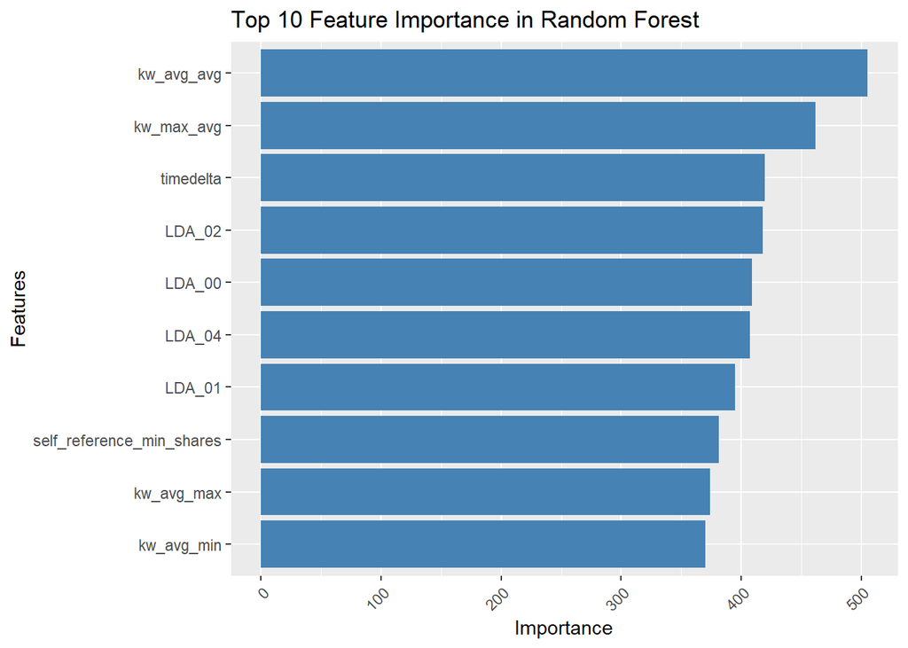

```r
# Create a bar plot for the top 10 most important features
# Load the required library
library(ggplot2)

# Create a data frame for the top 10 features and their importance scores
features <- c("kw_avg_avg", "kw_max_avg", "timedelta", "LDA_02", "LDA_00",
              "LDA_04", "LDA_01", "self_reference_min_shares", "kw_avg_max", "kw_avg_min")
importances <- c(505.1791, 461.6429, 419.6487, 418.0953, 408.6538,
                 407.4231, 394.6831, 381.2182, 374.1768, 370.0082)
feature_importance_df <- data.frame(Feature = features, Importance = importances)

# Order the data frame by Importance in descending order for plotting
feature_importance_df <- feature_importance_df[order(-feature_importance_df$Importance), ]

# Create a bar plot for the top 10 most important features
ggplot(feature_importance_df, aes(x = reorder(Feature, Importance), y = Importance)) +
  geom_bar(stat = "identity", fill = "steelblue") +
  labs(title = "Top 10 Feature Importance in Random Forest", x = "Features", y = "Importance") +
  theme(axis.text.x = element_text(angle = 45, hjust = 1)) +
  coord_flip()  # Flip the coordinates for horizontal bar chart
```

From the chart, we can conclude the following:

Keyword Average: The feature kw_avg_avg stands out as the most influential in the model, indicating that the average keyword relevance has the strongest relationship with the target variable.

Other Keyword Features: kw_max_avg, kw_avg_max, and kw_avg_min also appear among the top important features, highlighting that keyword-related metrics play a significant role in the predictions made by the model.

Timedelta: The feature timedelta comes in as the third most important, suggesting that the time factor may have a substantial effect on the outcome.

LDA Topics: Several features generated from Latent Dirichlet Allocation (LDA), which are likely topic probabilities (LDA_00, LDA_02, LDA_04, LDA_01), are also crucial, demonstrating the model’s reliance on the thematic structure of the data.

Self-Reference: The feature self_reference_min_shares is included in the list, indicating the model’s sensitivity to how much the content references itself in terms of shares.

# 5. Reommendations

# 6. Conclusion

Feature importance highlighted that keywords and topics derived from LDA analysis, as well as the timing of publication (‘timedelta’), are critical factors in predicting popularity. For content creators, this translates into a strategy that emphasizes keyword optimization, topical relevance, and timing of publication.

Challenges included managing the dataset’s complexity and ensuring model generalization. Future research could explore more advanced text analysis techniques and the incorporation of real-time engagement data.

The project underscores the potential of machine learning to inform and enhance content creation strategies, ultimately aiding publishers in effectively engaging their audience.